# In-Class Exercise 4: An Exploratory Data Analysis Checklist

Roger Peng’s checklist, applied to Freedom on the Move

Author

Alex Matney

Published

October 7, 2026

**NoteWhat is this exercise?**

In Exercise 3 you looked closely at how Freedom on the Move (FOTM) records *people*: names, kin, racial descriptions. Today you step back and look at the database as a whole, using a checklist written by the statistician Roger D. Peng for the first look at any new dataset.

This exercise is **adapted from Roger D. Peng, [*Exploratory Data Analysis with R*](https://bookdown.org/rdpeng/exdata/), Chapter 4, “[Exploratory Data Analysis Checklist](https://bookdown.org/rdpeng/exdata/exploratory-data-analysis-checklist.html).”** This chapter, as well as the following one, are listed as your reading for today’s class. Peng works through his checklist with a dataset of hourly air pollution readings. Each section below opens with the step from his chapter, summarized, and then applies it to FOTM.

As before, you’re graded on your documented effort to understand what you’re doing, not on mastery. Start in class (pairs or groups of 3 are welcome), finish at home, and commit your own work to GitHub.

**WarningNote on harmful language**

As in Exercise 3, the ads you’ll read describe people in the language of those who enslaved them. We read these words as historical evidence, and we make a commitment as a class to work with these records mindfully and aware of the violence in them. In other words: we will avoid repeating harmful language where it does not contribute to an interpretation or a historical argument.

## Setup

You need the FOTM tables in `data/FOTM/`, as in Exercise 3. This chunk loads the tidyverse, makes a folder for today’s output, and defines `read_fotm()`, the same helper you used in Exercise 3:

```r
library(tidyverse)
dir.create("output/exercise4", recursive = TRUE, showWarnings = FALSE)

read_fotm <- function(table) {
  file <- str_glue("data/FOTM/{table}.csv")
  suppressWarnings(                                   # the trailing-comma warning from Exercise 3
    read_csv(file,
             col_types = cols(.default = col_character()),   # read everything as text, change types later
             name_repair = "unique_quiet")
  ) %>%
    select(-starts_with("...")) %>%                   # drop the empty column the trailing comma creates
    rename_with(~ .x %>% str_remove("^\\S+ ") %>% str_to_lower())   # "ADVERTISEMENT ID" becomes "id"
}
```

## 1. Formulate your question

> **Peng:** “A sharp question or hypothesis can serve as a dimension reduction tool that can eliminate variables that are not immediately relevant to the question.” It’s also worth asking early whether you have the right data to answer it. ([Peng, “Formulate your question”](https://bookdown.org/rdpeng/exdata/exploratory-data-analysis-checklist.html#formulate-your-question))

Peng starts from a broad question (“Are air pollution levels higher on the east coast than on the west coast?”) and sharpens it until it names one measure and one unit. We’ll do the same. A broad question:

> Where did people escape from slavery?

FOTM can’t answer that directly: it holds *advertisements*, not escapes.

1. Write your own sharp question about FOTM’s advertisements: one that names exactly what you’d count or measure, and for what unit (an ad, a newspaper, a state, a decade…).

Save your question for a possible future investigation. For the purpose of learning Peng’s checklist, we’ll pursue a question this database can actually answer:

> In which states were the advertisements in FOTM published?

## 2. Read in your data

> **Peng:** Read the data in, and note anything you had to do to make it readable. ([Peng, “Read in your data”](https://bookdown.org/rdpeng/exdata/exploratory-data-analysis-checklist.html#read-in-your-data))

Our question needs three tables: the ads, the newspapers they appeared in, and where those newspapers were published.

```r
ads        <- read_fotm("advertisement")   # one row per ad
newspapers <- read_fotm("newspaper")       # the newspaper each ad appeared in
locations  <- read_fotm("location")        # where each newspaper was published
```

Join them, the same way you joined tables in Exercises 1 and 3. Count the rows before and after. A join that has more rows than the original table is a warning sign.

```r
nrow(ads)
```

```
[1] 89601
```

```r
ads_place <- ads %>%
  left_join(newspapers %>% select(newspaper_id = id, newspaper = name, location_id),
            by = "newspaper_id") %>%
  left_join(locations %>% select(location_id = id, city, state),
            by = "location_id")

nrow(ads_place)   # should be the same as nrow(ads)
```

```
[1] 89601
```

## 3. Check the packaging

> **Peng:** Before opening the wrapped “present,” shake the box: how many rows and columns are there? And do they match what you expected? ([Peng, “Check the packaging”](https://bookdown.org/rdpeng/exdata/exploratory-data-analysis-checklist.html#check-the-packaging))

```r
nrow(ads)
```

```
[1] 89601
```

```r
ncol(ads)
```

```
[1] 12
```

```r
nrow(newspapers)
```

```
[1] 41551
```

```r
n_distinct(newspapers$name)   # how many different newspaper titles?
```

```
[1] 294
```

Titles aren’t the whole story: two papers can share a name, and one paper can move. So count the different newspapers by title **and** place of publication:

```r
ads_place %>%
  distinct(newspaper, city, state) %>%
  nrow()
```

```
[1] 261
```

2. What did the `distinct()` function do in the chunk above? Hint: take a peak at the documentation for the function with `?distinct`.
3. The `newspaper` table has 41,551 rows, but notice many different newspapers (unique pair of title + place) there are. So what is the **unit of analysis** in the `newspaper` table? In other words, what is one row?
4. Then find a title that appears in two places: did the paper move, are these two different papers, or is it an error?

**TipTip:**

To answer the question, you need two things for each title: **where** it was published, and **when**. Build your chunk in three steps:

1. **One row per title and place, with the evidence.** Start from `ads_place`, group by title and place, and summarize how many ads each one has and when they were published:

```r
   ads_place %>%
     group_by(______) %>%
     summarize(ads   = n(),
               first = min(________),
               last  = max(________),
               .groups = "drop")
```

2. **Count places per title.** Pipe that into `add_count(_______)` so that each row shows how many places its title appears in.
3. **Keep only titles with more than one place:** `filter(___ > ___)`.

**How to read the result:**

- **Dates follow one another** (one place stops, the other starts): the paper probably **moved**.
- **Dates overlap, or are years apart:** probably **two different papers** with the same name.
- **Same dates in both places, or a single stray ad:** probably a **data-entry error**.

Write your findings here:

## 4. Run `str()`

> **Peng:** `str()` shows the class of every column. Make sure numbers are numbers, dates are dates, and text is text. ([Peng, “Run str()”](https://bookdown.org/rdpeng/exdata/exploratory-data-analysis-checklist.html#run-str))

```r
str(ads_place)
```

```
tibble [89,601 × 16] (S3: tbl_df/tbl/data.frame)
 $ id               : chr [1:89601] "005aa6c1-e81b-406a-8598-284b7aaa46a0" "54f3927b-20f8-466c-86d0-3de352ffe86a" "8e3eeeda-9ed8-4801-9801-87e8c6878366" "cc633587-918f-424c-9e8c-30a5867440fb" ...
 $ transcription    : chr [1:89601] "STOP THE RUNAWAY.--Ranaway form the subscriber, on the 1st day of January, 1843, a negro boy named HUDSON, abou"| __truncated__ "$30 Reward.\nRANAWAY, while on trial at the house of Madam Pucheu, on the 7th inst., a Bright Mulatto Man named"| __truncated__ "FIVE …
 $ type             : chr [1:89601] "ENSLAVER" "ENSLAVER" "ENSLAVER" "NOT_PROVIDED" ...
 $ page_number      : chr [1:89601] "3" "{undefined value}" "{undefined value}" "{undefined value}" ...
 $ publication_date : chr [1:89601] "1843-01-18" "1837-07-14" "1783-09-13" "1829-12-17" ...
 $ digital_object_id: chr [1:89601] "04aa9ba2-b870-4ce5-b4d4-9a3f50dda107" "6ba672d3-c650-4a9f-b6d4-adecce4d0c9a" "7bcf45ef-ed36-41ed-9b01-5735c6b46b46" "7c3395d8-4538-4c7f-8bff-372a66e7bceb" ...
 $ language_id      : chr [1:89601] "0bd6aee5-32dd-453c-8ed5-76bd9788465a" "0bd6aee5-32dd-453c-8ed5-76bd9788465a" "0bd6aee5-32dd-453c-8ed5-76bd9788465a" "0bd6aee5-32dd-453c-8ed5-76bd9788465a" ...
 $ advertiser_id    : chr [1:89601] "{undefined value}" "{undefined value}" "{undefined value}" "{undefined value}" ...
 $ newspaper_id     : chr [1:89601] "dc738fca-76bd-432c-93ea-a04d200d948d" "c5993adc-4bee-4c12-a104-9bf7119308af" "d47cb36b-c2f4-499f-bfdf-7f56f0ef8003" "12d38785-dfdf-4dbc-a9c6-3ccb0e8d6448" ...
 $ date_modified    : chr [1:89601] "2020-02-11T21:33:15.777086" "2018-11-21T13:17:16.785462" "2018-11-19T16:55:13.986702" "2019-02-07T15:39:44.878696" ...
 $ complete         : chr [1:89601] "true" "false" "true" "true" ...
 $ visible          : chr [1:89601] "true" "true" "true" "true" ...
 $ newspaper        : chr [1:89601] "Weekly Standard" "The Daily Picayune" "The Royal Gazette" "Charleston Mercury" ...
 $ location_id      : chr [1:89601] "d2d21cf6-f1e4-4bd0-aedb-3ba44b04aa5a" "026f5472-34b7-4c69-aff8-9ae5cd62e07a" "0127c7e1-ff75-4d8e-bd1d-c4ff4c7f0412" "0afd2704-9c29-4f31-9ffe-3627c61e7958" ...
 $ city             : chr [1:89601] "Raleigh" "New Orleans" "{undefined value}" "Charleston" ...
 $ state            : chr [1:89601] "US-NC" "US-LA" "US-NY" "US-SC" ...
```

Every column is text, because `read_fotm()` reads everything as text on purpose. To work with time we need a real date. `year()` (from the lubridate package, part of the tidyverse) pulls out the year:

```r
ads_place <- ads_place %>%
  mutate(date = as.Date(publication_date),
         year = year(date))

sum(is.na(ads_place$date))   # how many dates failed to convert?
```

```
[1] 0
```

## 5. Look at the top and the bottom of your data

> **Peng:** Look at the first and last rows. Problems often hide at the end of a file, and for data over time, check that the first and last dates are what you expect. ([Peng, “Look at the top and the bottom of your data”](https://bookdown.org/rdpeng/exdata/exploratory-data-analysis-checklist.html#look-at-the-top-and-the-bottom-of-your-data))

Our data are over time, so sort by date first:

```r
ads_place %>%
  arrange(date) %>%
  select(date, newspaper, city, state) %>%
  head()
```

| date | newspaper | city | state |
| --- | --- | --- | --- |
| 1704-06-26 | The Boston News-Letter | Boston | US-MA |
| 1704-07-17 | The Boston News-Letter | Boston | US-MA |
| 1704-10-02 | The Boston News-Letter | Boston | US-MA |
| 1705-12-10 | The Boston News-Letter | Boston | US-MA |
| 1706-07-22 | The Boston News-Letter | Boston | US-MA |
| 1708-11-15 | The Boston News-Letter | Boston | US-MA |

```r
ads_place %>%
  arrange(date) %>%
  select(date, newspaper, city, state) %>%
  tail()
```

| date | newspaper | city | state |
| --- | --- | --- | --- |
| 1867-08-23 | Greensborough Patriot | Greensboro | US-NC |
| 1867-11-29 | Greensborough Patriot | Greensboro | US-NC |
| 1868-10-01 | Greensborough Patriot | Greensboro | US-NC |
| 1872-02-01 | Weekly Pioneer | Asheville | US-NC |
| 1874-04-04 | Weekly Pioneer | Asheville | US-NC |
| 1894-04-25 | Weekly Raleigh Register | Raleigh | US-NC |

5. Discuss with your pair or group: what are the earliest and latest dates? Which one surprises you, and why?

## 6. Check your “n”s

> **Peng:** Count things, and compare the counts with *landmarks*: numbers you know should be true. If you expect 1,000 people and find 20, something’s wrong. ([Peng, “Check your ’n’s”](https://bookdown.org/rdpeng/exdata/exploratory-data-analysis-checklist.html#check-your-ns))

A landmark for us: every ad in FOTM is a scan of a newspaper page. If FOTM is a database of *transcribed* ads, nearly every row should have a transcription. Does it? (`{undefined value}` is one of FOTM’s ways of saying “nothing here,” as you saw in Exercise 3.)

```r
ads_place <- ads_place %>%
  mutate(has_text = !is.na(transcription) & transcription != "{undefined value}")

ads_place %>% count(has_text)
```

| has_text | n |
| --- | --- |
| FALSE | 62470 |
| TRUE | 27131 |

Plot the ads by decade, colored by whether they’ve been transcribed. `floor(year / 10) * 10` turns 1823 into 1820:

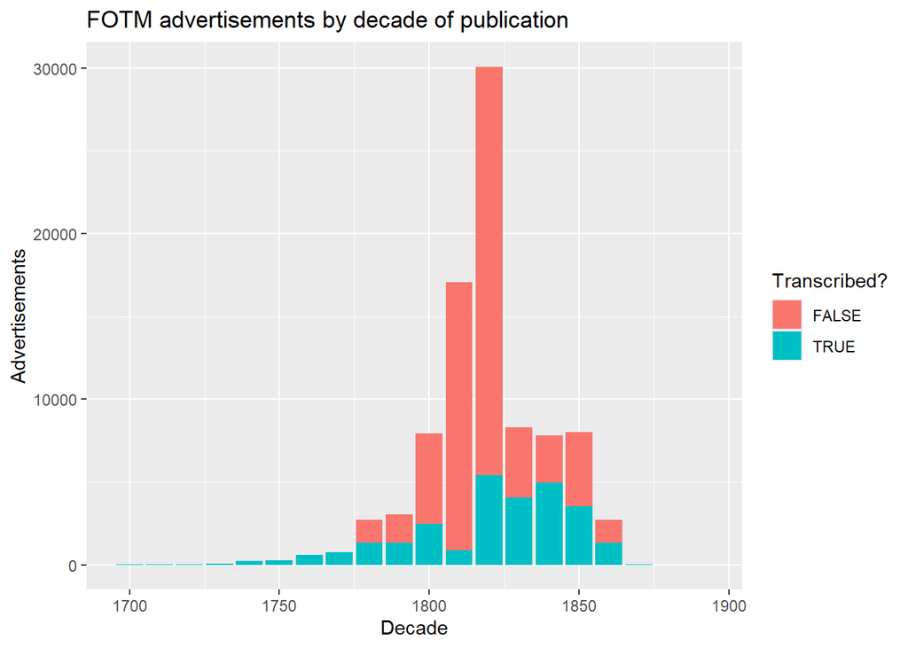

```r
ads_place %>%
  mutate(decade = floor(year / 10) * 10) %>%
  count(decade, has_text) %>%
  ggplot(aes(x = decade, y = n, fill = has_text)) +
  geom_col() +
  labs(title = "FOTM advertisements by decade of publication",
       x = "Decade", y = "Advertisements", fill = "Transcribed?")
```

6. What share of the ads have a transcription? Which decades have the most untranscribed ads? Without the color, what would a reader conclude from the height of the 1810s and 1820s bars?

## 7. Validate with at least one external data source

> **Peng:** Check your data against something *outside* the dataset. Even a single number will do: Peng compares his ozone readings with the national air-quality standard to see if they’re the right order of magnitude. ([Peng, “Validate with at least one external data source”](https://bookdown.org/rdpeng/exdata/exploratory-data-analysis-checklist.html#validate-with-at-least-one-external-data-source))

Two historical landmarks:

- *The Boston News-Letter*, the first continuously published newspaper in British North America, began in April **1704**.
- The Thirteenth Amendment abolished slavery in the United States in December **1865**.

Your earliest ad should be no earlier than 1704, and runaway-slave ads should stop after 1865. Check the first, then read the ads published after 1865:

```r
ads_place %>% filter(year == min(year)) %>% select(date, newspaper)
```

| date | newspaper |
| --- | --- |
| 1704-10-02 | The Boston News-Letter |
| 1704-07-17 | The Boston News-Letter |
| 1704-06-26 | The Boston News-Letter |

```r
after_1865 <- ads_place %>%
  filter(year > 1865) %>%
  arrange(date)

after_1865 %>% count(newspaper, state)
```

| newspaper | state | n |
| --- | --- | --- |
| Greensborough Patriot | US-NC | 12 |
| Weekly Pioneer | US-NC | 2 |
| Weekly Raleigh Register | US-NC | 1 |

```r
after_1865 %>% pull(transcription) %>% cat(sep = "\n\n----------\n\n")
```

```
Notice-.
Two black boys, named Thomas and Phillip, left my house on Sunday 2nd day of December, 1865, without leave. Thomas aged about 16 years, Phillip aged about 12 years Also one black boy named Thomas Scales left about the 3rd of October, 1865. Said boys have been bound to me by the Assistant Superintend…
 DR.B.L. COLE
73--3w Summerfield, Guilford County, N.C.

----------

One Cent Reward!--Carter Taylor a colored boy bound to me is going at large. I hereby warn all persons against harboring or employing him, particularly the man who was seen to lift him in his wagon at the Court House on Thursday of Court week. Unless he returns him directly with his clothes, I shall…
WM. S. FONTAINE
jun1 97-4w*c.rr

----------

Ranaway.--On the 23rd day of April a negro boy Ambrose. Said boy is 5 feet, 7 or 8 inches high, black complexion, face full with sluggish look, weighs about 165 pounds, has a scar on his breast, and is about 20 years of age. Had on when he left a brown lindsay coat and black pants. The above boy was…
GEORGE BOWERS
 2-tf Thomasville, N.C.

----------

5 Cent Reward.-
Julius Carter, a boy of color, indentured to me by the County Court of Guilford has absconded from my premises and quited my service. This is to forewarn all persons not to harbor or employ said apprentice. A reward of five cents is offered for his apprehension and delivery to me.
30-3w JOHN G. EFLAND.

----------

**Not an enslaved person. All entries will be left blank so as not to be mistaken in the system."

5 cents Reward.-- Dinah Staples, an indentured apprentice has left my service. -- This is to forewarn all persons not to harbor or employ the said girl, for whose return to me a reward of five cents will be paid.
30-3w*
A.P. NEWHART

----------

5 Cents Reward.
.WILLIAM STEELE,son of Dillard Steele, who was indentured to me by Guilford county court, has absconded himself from my employment. This is to forewarn all persons not to harbor or employ the said William Steele, and for the delivery of him to me I will pay a reward of five cents.
42-3w G.F. SHOFFNER.

----------

July 2, 1867.
```

[output cut: 49 more lines]

```
All persons are hereby forwarned from harboring said boys or trading with them in any way.
Any person who will arrest or apprehend said boys, or give any information that will lead to their recovery will be suitably rewarded.
Address us at Stocksville, Buncombe county N. C.
M. ROBERTS,
JOSEPH LONG,
March 13th, 1874.
[Mar. 14 tf.

----------

100 Dollars Reward.
RANAWAY in July 1847, a negro man by the name of Buck. He is a yellow complexion,[illegible] about five feet six inches high, rather bow legged, very quick in his movements, and when spoken to very slow to answer. He was in the possession of Robert F. Morris at Hillsborough, when he went away, and i…
WM. J. HAMLETT.
Mt. Tirza, Person, N. C.
April 16, 1849. 32--2m.
```

7. Does the earliest ad agree with the first landmark? For the ads after 1865: who is running away, from whom, and who “bound” them? What do these ads tell you about the end of slavery, and why might FOTM’s editors have included them? Is any of them probably a data-entry error?

## 8. Try the easy solution first

> **Peng:** Give the simplest possible answer to your question first, without worrying yet about whether it’s right. Then question it. ([Peng, “Try the easy solution first”](https://bookdown.org/rdpeng/exdata/exploratory-data-analysis-checklist.html#try-the-easy-solution-first))

The easy answer to “In which states were the ads published?”: count the ads by state.

```r
ads_by_state <- ads_place %>%
  count(state, name = "ads", sort = TRUE)

ads_by_state
```

| state | ads |
| --- | --- |
| US-DC | 26929 |
| US-SC | 13930 |
| US-VA | 12231 |
| US-LA | 11790 |
| US-MD | 7414 |
| US-GA | 6311 |
| US-NC | 5192 |
| US-AL | 2830 |
| US-TN | 758 |
| US-NY | 543 |

[output cut: 10 more lines]

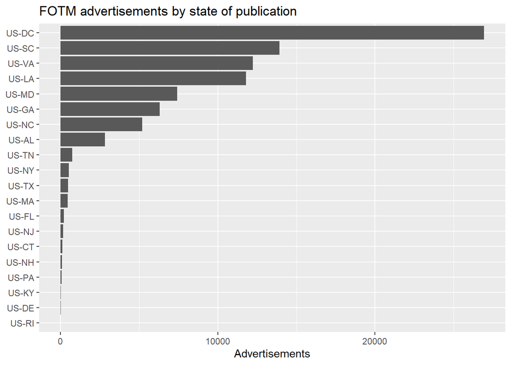

```r
ggplot(ads_by_state, aes(x = ads, y = reorder(state, ads))) +
  geom_col() +
  labs(title = "FOTM advertisements by state of publication",
       x = "Advertisements", y = NULL)
```

8. Which state comes first? Does that match what you know about where slavery was concentrated in the United States?

## 9. Challenge your solution

> **Peng:** The easy answer should never “hold the day.” Look for ways to challenge it, especially when it matches what you expected. ([Peng, “Challenge your solution”](https://bookdown.org/rdpeng/exdata/exploratory-data-analysis-checklist.html#challenge-your-solution))

### Challenge 1: Which newspapers?

A state’s count is the sum of its newspapers. Which newspapers make up the top state?

```r
top_state <- ads_by_state$state[1]

ads_place %>%
  filter(state == top_state) %>%
  count(newspaper, has_text, sort = TRUE)
```

| newspaper | has_text | n |
| --- | --- | --- |
| Daily National Intelligencer | FALSE | 24142 |
| Washington DC National Intelligencer | TRUE | 1908 |
| Washington DC National Intelligencer | FALSE | 711 |
| Daily National Intelligencer | TRUE | 168 |

### Challenge 2: Count only the ads someone has read

Redo the easy solution, counting only transcribed ads:

```r
ads_place %>%
  filter(has_text) %>%
  count(state, name = "transcribed_ads", sort = TRUE)
```

| state | transcribed_ads |
| --- | --- |
| US-LA | 8041 |
| US-NC | 5186 |
| US-SC | 3414 |
| US-GA | 2339 |
| US-AL | 2076 |
| US-DC | 2076 |
| US-MD | 1279 |
| US-VA | 687 |
| US-TN | 617 |
| US-MA | 469 |

[output cut: 10 more lines]

9. How much of the top state’s lead comes from one newspaper? How many of that paper’s ads have been transcribed? Which state comes first when you count only transcribed ads?

### Challenge 3: Compare with the enslaved population

A second external source: the number of enslaved people in each slave state in 1860, from the U.S. Census. It’s only a rough yardstick (the ads span 160 years, the census is one year), but it shows the order of magnitude we should expect.

```r
census_1860 <- tribble(
  ~state,  ~state_name,            ~enslaved_1860,
  "US-AL", "Alabama",               435080,
  "US-AR", "Arkansas",              111115,
  "US-DE", "Delaware",                1798,
  "US-DC", "District of Columbia",    3185,
  "US-FL", "Florida",                61745,
  "US-GA", "Georgia",               462198,
  "US-KY", "Kentucky",              225483,
  "US-LA", "Louisiana",             331726,
  "US-MD", "Maryland",               87189,
  "US-MS", "Mississippi",           436631,
  "US-MO", "Missouri",              114931,
  "US-NC", "North Carolina",        331059,
  "US-SC", "South Carolina",        402407,
  "US-TN", "Tennessee",             275719,
  "US-TX", "Texas",                 182566,
  "US-VA", "Virginia",              490865
)

census_1860 %>%
  left_join(ads_by_state, by = "state") %>%
  mutate(ads = replace_na(ads, 0),                      # no ads at all becomes 0, not NA
         ads_per_1000_enslaved = round(ads / enslaved_1860 * 1000, 1)) %>%
  arrange(desc(ads_per_1000_enslaved))
```

| state | state_name | enslaved_1860 | ads | ads_per_1000_enslaved |
| --- | --- | --- | --- | --- |
| US-DC | District of Columbia | 3185 | 26929 | 8454.9 |
| US-MD | Maryland | 87189 | 7414 | 85.0 |
| US-LA | Louisiana | 331726 | 11790 | 35.5 |
| US-SC | South Carolina | 402407 | 13930 | 34.6 |
| US-VA | Virginia | 490865 | 12231 | 24.9 |
| US-NC | North Carolina | 331059 | 5192 | 15.7 |
| US-GA | Georgia | 462198 | 6311 | 13.7 |
| US-DE | Delaware | 1798 | 21 | 11.7 |
| US-AL | Alabama | 435080 | 2830 | 6.5 |
| US-FL | Florida | 61745 | 213 | 3.4 |

[output cut: 6 more lines]

10. Which states have the most ads per 1,000 enslaved people, and which have none at all? What does that suggest about how FOTM chose (or was able to find) its newspapers?
11. Last challenge, from Exercise 3: the George, Celia, and Sarah ad ran 20 times in the *Charleston Mercury*, and each printing is a separate row in `ads`. How would reprints affect the counts above? How might you find them? (You don’t need to write the code.)

## 10. Follow up

> **Peng:** At the end, ask three questions. Do you have the right data? Do you need other data? Do you have the right question? ([Peng, “Follow up questions”](https://bookdown.org/rdpeng/exdata/exploratory-data-analysis-checklist.html#follow-up-questions))
12. Answer Peng’s three questions for our question (“In which states were the advertisements in FOTM published?”). Then return to the broad question we set aside in step 1, “Where did people escape from slavery?” What would you need to answer it, and what can FOTM honestly tell you about it?
13. Rewrite the question you wrote in step 1, using what you learned in this checklist.

## Save, Commit, Push

The counts you made are small summaries of FOTM, so they can be committed. FOTM’s own files stay in `data/FOTM/`.

```r
write_csv(ads_by_state, "output/exercise4/ads_by_state.csv")
```

Commit this file and `output/exercise4/` with a message like “Exercise 4: EDA checklist on FOTM,” then **Push origin**. As always, if anything from `data/FOTM/` shows up in GitHub Desktop’s Changes list, stop and ask me.

**TipSources**

- Roger D. Peng, *Exploratory Data Analysis with R* (Leanpub, 2015–2020), Chapter 4, “Exploratory Data Analysis Checklist,” [bookdown.org/rdpeng/exdata](https://bookdown.org/rdpeng/exdata/exploratory-data-analysis-checklist.html). The structure of this exercise and the summarized steps are his.
- *Freedom on the Move: A Database of Fugitives from American Slavery*, Cornell University, freedomonthemove.org. Full database download used in this course: September 2026.
- Enslaved population by state, 1860 U.S. Census, as tabulated in “[Population by Color and Status: U.S. Slave States, 1860](https://terpconnect.umd.edu/~sfmiller/population%20statistics,%201860.htm).”